# Analyzing Swecris, Case, Cordis, and OpenAire Datasets

### Data quality after matching

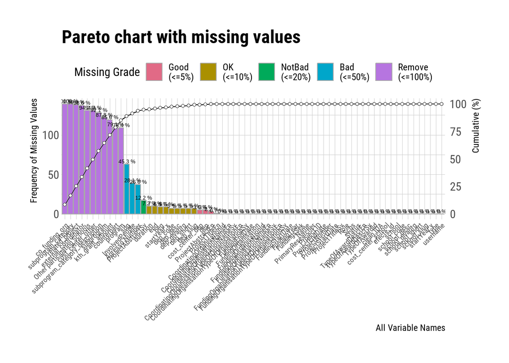

Figure 7. Pareto chart for missing values (counts and proportions) in the reduced CASE dataset (i.e. the remaining projects that satisfies the matching criterion using clean ID’s).

```r
bazzi.na.Total(x = MissCheck.1, col = "black",typographic = T) +
  theme(axis.text.x = element_text(size = 7),
        axis.title.x = element_text(size = 9),
        axis.title.y = element_text(size = 9),
        axis.title.y.right = element_text(size = 9))
```

**Results (1/3)**

1. The number of project matches depend on how ID standardization is done.
2. Using the two predominant ID styles in sweCris (see above) as a reference, yields 139 distinct project matches. Generally, most CASE ID’s are inconsistently written, which makes it very difficult to merge against sweCris. The issue is further exacerbated by variable ID formats in sweCris. But is generally better than CASE.
3. Of the **384 CASE projects** with a clean ID, only ~36% (N=139) could be matched against the sweCris dataset.
4. Viewed altogether, only 5.32% of unique CASE projects (N=2611) could be detected in sweCris using project ID as an identifier. In terms of ‘hypothetical matches’ (see Table 1) , the matching level rise to ~18%.
5. Overall, despite the low number of project matches, the added information retrieved via sweCris is rather complete (column-wise). This is unsurprising as the data quality in sweCris tends to be better.

```r
# Venn diagram showing project overlap based on project ID's.
mP1 <- draw.pairwise.venn(area1= 3137,area2 = 746,
                          cross.area = 139,
                          category = c("sweCris projects with an ID",
                                       "CASE projects with an ID"),
                          fill = c("grey80","#7b0323"),
                          scaled = T,cex = 1,
                          rotation.degree = 45)
```

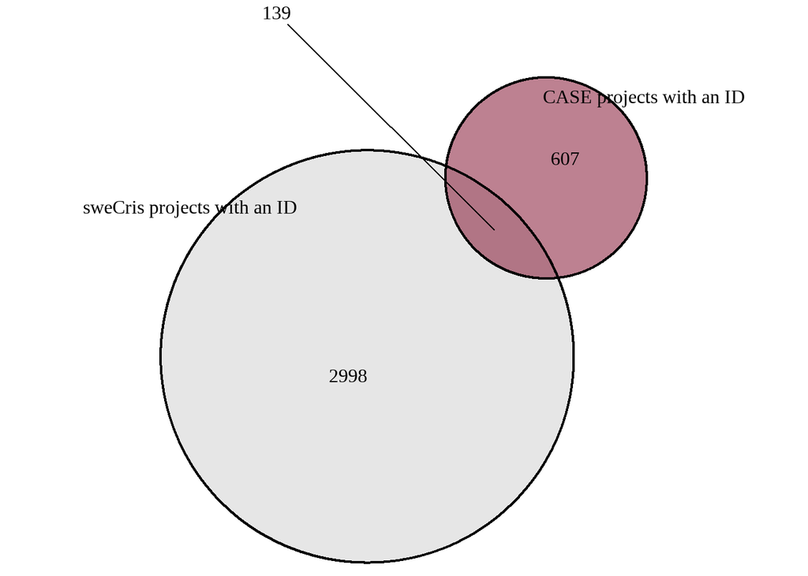

Figure 8. Venn diagram showing project overlap based on project ID’s. Area 1 (Grey) = sweCris projects limited to funding organizations shown in Table 1. Area 2 (Red) = CASE projects.

```r
ggarrange(mP1) + theme(aspect.ratio = 1)
```

```r
cleanID.CASE %>% group_by(Role) %>% count(sort = T)
```

## 1B. Key: Project number

> **In-exact matches on ID**

```r
# Fuzzy matching.
Fuzz.ID <- cleanID.CASE %>%
  stringdist_inner_join(x = sw.Df,by = c(ProjectId = "clean.IDA")) %>%
  filter(!duplicated(clean.IDA)) %>%
  filter(!duplicated(Name)) # 332 matches?

Fuzz.ID["lev"] <- lev <- levenshteinSim(Fuzz.ID$clean.IDA,Fuzz.ID$ProjectId)
Fuzz.ID["jaro"] <- jaro <- jarowinkler(Fuzz.ID$clean.IDA,Fuzz.ID$ProjectId)
```

**Evaluating fuzzy matching**

```r
knitr::kable(slice_head(Fuzz.ID[,c("clean.IDA","ProjectId","lev","jaro")],n = 10),
  caption = "Table 3. Fuzzy matching. Lev = levenshtein distance (%), jaro = jaro-winkler distance.",
  digits = 2) %>%
  kable_styling()
```

Table 3. Fuzzy matching. Lev = levenshtein distance (%), jaro = jaro-winkler distance.

| clean.IDA | ProjectId | lev | jaro |
| --- | --- | --- | --- |
| 2022-04907_VR | 2022-00901_VR | 0.85 | 0.92 |
| 2022-04900_VR | 2022-00901_VR | 0.85 | 0.95 |
| 2022-01905_VR | 2022-00901_VR | 0.85 | 0.95 |
| 2022-06078_VR | 2022-01079_VR | 0.85 | 0.94 |
| 2022-01284_Vinnova | 2022-01624_Vinnova | 0.89 | 0.98 |
| 2022-01725_Vinnova | 2022-01624_Vinnova | 0.89 | 0.96 |
| 2022-01004_Vinnova | 2022-01624_Vinnova | 0.89 | 0.96 |
| 2022-01614_Vinnova | 2022-01624_Vinnova | 0.94 | 0.98 |
| 2022-01240_Vinnova | 2022-01624_Vinnova | 0.89 | 0.98 |
| 2022-01600_Vinnova | 2022-01624_Vinnova | 0.89 | 0.96 |

**Miss-classification rate**

```r
paste(round(100-(which(Fuzz.ID$lev == 1.0000000) %>%
                   length()/(length(Fuzz.ID$lev)))*100,2),"%")
```

```
[1] "90.72 %"
```

## 2. Key: Project Title.

```r
# How many NA project titles are there in sweCris?
sum(is.na(sw.Df$ProjectTitleSv)) # 77.
sum(is.na(sw.Df$ProjectTitleEn)) # 420. Seem very excessive! Something have happend.
# How many NA project titles are there in CASE?
sum(is.na(ca.Df$Name)) # 3
```

#### **Whats the proportion of Swedish versus English titles in Case?**

```r
# Add
ca.Df["language"] <- NA
# Language identifier
system.time(
  for(i in 1:length(ca.Df$Name)) {
  ca.Df$language[[i]] <- tolower(cld2::detect_language(text = ca.Df$Name[[i]],
                                                       plain_text = T,
                                                       lang_code = F))
}
)

# Correct
ca.Df$language[ca.Df$language == "norwegian"] <- "swedish"

# Summary.
ca.Df %>%
  group_by(ca.Df$language) %>%
  count(sort = T) %>%
  print(n=45)

# Unknowns, are a mix of Swedish & English titles.
ca.Df$language[is.na(ca.Df$language)] <- "Unknown"

# Other languages?
ca.Df %>% group_by(Name,language) %>%
  dplyr::select(Name,language) %>%
  filter(language == "welsh" | language == "uzbek" |
         language == "turkish" | language == "portuguese" |
         language == "nyanja" | language == "kurdish" |
         language == "indonesian" | language == "hungarian" |
         language == "galician" | language == "croatian" |
         language == "catalan" | language == "albanian" |
         language == "afrikaans" | language == "spanish" |
         language == "kinyarwanda" | language == "ganda" |
         language == "estonian" | language == "basque" |
         language == "german") %>%
  print(n = 28)
```

```r
# Subset based on intersection.
# Remove extra spaces and use case-folding to improve intersection.
merge_titles <- c(generics::intersect(
  x = gsub("\\s+"," ", iconv(tolower(na.omit(ca.Df$Name)),to = "ASCII//TRANSLIT")),
  y = gsub("\\s+"," ",iconv(tolower(na.omit(sw.Df$ProjectTitleSv)),
                            to = "ASCII//TRANSLIT"))),
  generics::intersect(x = gsub("\\s+"," ",
                               iconv(tolower(na.omit(ca.Df$Name)),to = "ASCII//TRANSLIT")),
  y = gsub("\\s+"," ",iconv(tolower(na.omit(sw.Df$ProjectTitleEn)),
                            to = "ASCII//TRANSLIT"))))
# Any duplicates? Yes.
duplicated(merge_titles)
# Remove.
merge_titles <- unique(merge_titles) # 140
# Subset
sub.ca.Df.2 <- ca.Df
sub.ca.Df.2$Name <- gsub("\\s+"," ",iconv(tolower(ca.Df$Name),
                                          to = "ASCII//TRANSLIT"))

sub.ca.Df.2 <- sub.ca.Df.2[sub.ca.Df.2$Name %in% merge_titles, ]
sub.ca.Df.2$Name[duplicated(sub.ca.Df.2$Name)] # duplicate?

# Clean.
sub.ca.Df.2 <-
  sub.ca.Df.2 %>%
  group_by(Name) %>%
  filter(!duplicated(Name))

# sweCris modification to enable inner-join.
modify.sw.Df <- sw.Df
modify.sw.Df$ProjectTitleSv <- gsub("\\s+"," ",
                                    iconv(tolower(sw.Df$ProjectTitleSv),
                                          to = "ASCII//TRANSLIT"))
modify.sw.Df$ProjectTitleEn <- gsub("\\s+"," ",
                                    iconv(tolower(sw.Df$ProjectTitleEn),
                                          to = "ASCII//TRANSLIT"))

# Merge in a two step fashion.
parseSwe <- ca.Df %>%
  filter(!is.na(Name)) %>%
  mutate(Name = gsub("\\s+"," ",iconv(tolower(na.omit(ca.Df$Name)),
                                      to = "ASCII//TRANSLIT"))) %>%
  group_by(Name) %>%
  filter(!duplicated(Name)) %>%
  inner_join(modify.sw.Df, by = c("Name" = "ProjectTitleSv"))
  # distinct(Name)

parseEng <- ca.Df %>%
  filter(!is.na(Name)) %>%
  mutate(Name = gsub("\\s+"," ",iconv(tolower(na.omit(ca.Df$Name)),
                                      to = "ASCII//TRANSLIT"))) %>%
  group_by(Name) %>%
  filter(!duplicated(Name)) %>%
  inner_join(modify.sw.Df, by = c("Name" = "ProjectTitleEn"))
  # distinct(Name)

# Match by project title enrichment.
Match.2 <- rbind(parseSwe,parseEng)
Match.2 <- Match.2 %>% filter(!duplicated(Name))
```

```r
# Create one title field in sweCris.
sw.Df <- sw.Df %>% mutate(Unified.Title =
                            ifelse(is.na(ProjectTitleSv),
                                   ProjectTitleEn,ProjectTitleSv))
# Duplicated Project Names in Case.
ca.Df %>% add_count(Name) %>% filter(n > 1) %>% distinct() %>%
  group_by(Name) %>% summarise(n = n()) # %>% count(n)

# What about in sweCris?
sw.Df %>% add_count(Unified.Title) %>% filter(n > 1) %>% distinct() %>%
  group_by(Unified.Title) %>% summarise(n = n()) %>% count(n)
```

```
Storing counts in `nn`, as `n` already present in input
ℹ Use `name = "new_name"` to pick a new name.
```

**Results (2/3)**

1. 140 exact project matches based on **Project Title.** This is on par with the number of matches captured using Project ID. An additional 11 projects could be added based on fuzzy matching using a threshold of 0.85.
2. **Data-quality issues:** Three NA’s in the Name/Title field in Case were found. At least 4 project titles have triplet occurrences, and 15 titles occur twice (i.e. true duplicates) in Case.
3. **Data-quality issues:** In sweCris there are 78 project titles that are pure duplicates, 5 triplets, and four quadruplets.

```r
## Venn diagram showing projects overlap based on project title.
mP2 <- draw.pairwise.venn(area1= 3068,area2 = 746,
                          cross.area = 140,
                          category   = c("SweCris-titled projects",
                                         "CASE-titled projects"),
                          fill = c("grey80","darkcyan"),
                          scaled = T,cex = 1,
                          rotation.degree = 45)
```

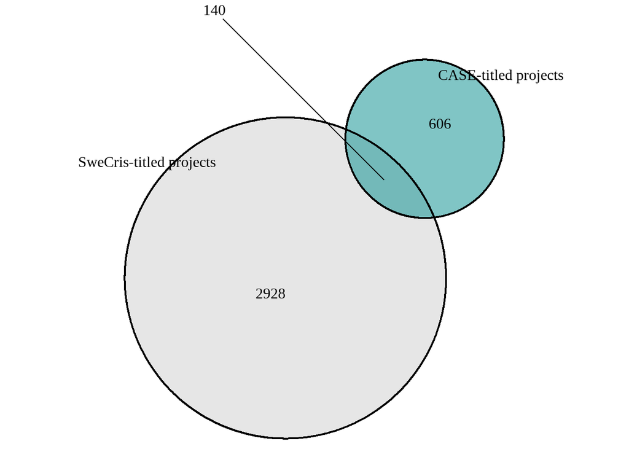

```r
ggarrange(mP2) + theme(aspect.ratio = 1)
```

**Combined results**

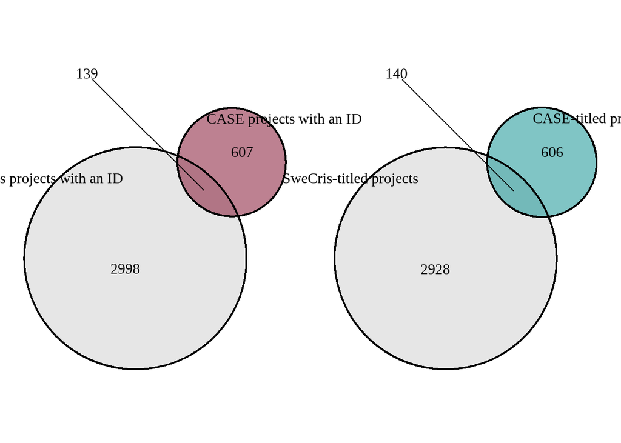

Comparison of results

```r
ggarrange(mP1,mP2) + theme(aspect.ratio = 1/2)
```

**Does ID vs Title identifiers return the same matching projects?**

```r
# Project intersections.
generics::intersect(gsub("\\s+"," ",
                         iconv(tolower(na.omit(MissCheck.1$Name)),
                               to = "ASCII//TRANSLIT")),Match.2$Name)
# Projects set apart.
generics::setdiff(gsub("\\s+"," ",
                       iconv(tolower(na.omit(MissCheck.1$Name)),
                             to = "ASCII//TRANSLIT")),Match.2$Name)
# Combine.
Total.M1 <- merge(MissCheck.1,Match.2,all = T)
Total.M1$Name <- iconv(tolower(Total.M1$Name),to = "ASCII//TRANSLIT")
# Subset.
Total.M1 <- Total.M1 %>% filter(!duplicated(Name))
```

**Fuzzy-matching based on title sound**

**Gestalt pattern matching**

```r
fuzzy_Title_SX <- ca.Df %>%
  fuzzyjoin::stringdist_inner_join(sw.Df, by=c(Name="Unified.Title"),
                       method="soundex", max_dist = 0) %>%
  filter(!duplicated(ProjectId)) %>%
  filter(!duplicated(Name))

fuzzy_Title_SX["JW"] <- lev <- jarowinkler(fuzzy_Title_SX$Name,
                                           fuzzy_Title_SX$Unified.Title)
# Check again
EXA <- fuzzy_Title_SX %>%
  filter(JW >= .85)

EXA <- EXA %>%
  mutate(ProjectTitleEn = gsub("\\s+"," ",iconv(tolower(EXA$ProjectTitleEn),
                                                to = "ASCII//TRANSLIT")))
# How many extra? 11 projects.
rM <- generics::intersect(Match.2$ProjectTitleEn,
                          gsub("\\s+"," ",iconv(tolower(EXA$ProjectTitleEn),
                                                to = "ASCII//TRANSLIT")))

EXB <- EXA[!(EXA$ProjectTitleEn %in% c(rM)), ]

# Combine extras with exact title matches.
Match.2B <- rbind(Match.2,EXB)
Match.2B <- Match.2B %>% filter(!duplicated(Name))
```

## 3. Key: Primary Researcher

1. The **InvolvedPeople** column have a complex string structure with relevant information that ought to be parsed out to facilitate maximum matching with the CASE database. The main problem here is that the name of the project leaders, including participating researchers are bind into poorly structured text strings. To circumvent, I have attempted to parse out **name** and **role** based on their general position in each string.
2. The **primary researcher** information is missing from 696 projects (22%) in SweCris. 17 of these do however include partial information, but not the name of the PI. Why?
3. The name of 2441 Principal Investigators (77.81%) could successfully be retrieved via sweCris.
4. 69 exact name matches between CASE and sweCris.

```r
sw.Df["PrimaryResearcher"] <- ""
sw.Df["Leading.Role"] <- ""

# Generalize.
for(i in 1:length(sw.Df$InvolvedPeople)) {
  # Index.
  iX <- strsplit(sw.Df$InvolvedPeople[[i]],"¤")[[1]][-c(1:3)]
  # Attain name via PI position
  sw.Df$PrimaryResearcher[[i]] <-
    iX[grep("Principal Investigator",
            strsplit(sw.Df$InvolvedPeople[[i]],"¤")[[1]][-c(1:3)])[1]-2]
  # Clean names, with no extra spaces.
  sw.Df$PrimaryResearcher[[i]] <- gsub("\\s+"," ",sw.Df$PrimaryResearcher[[i]])
  # Remove accents.
  sw.Df$PrimaryResearcher[[i]] <- iconv(sw.Df$PrimaryResearcher[[i]],
                                        to = "ASCII//TRANSLIT")
  # Role.
  sw.Df$Leading.Role[[i]] <-
    iX[grep("Principal Investigator",
            strsplit(sw.Df$InvolvedPeople[[i]],"¤")[[1]][-c(1:3)])[1]]
}
```

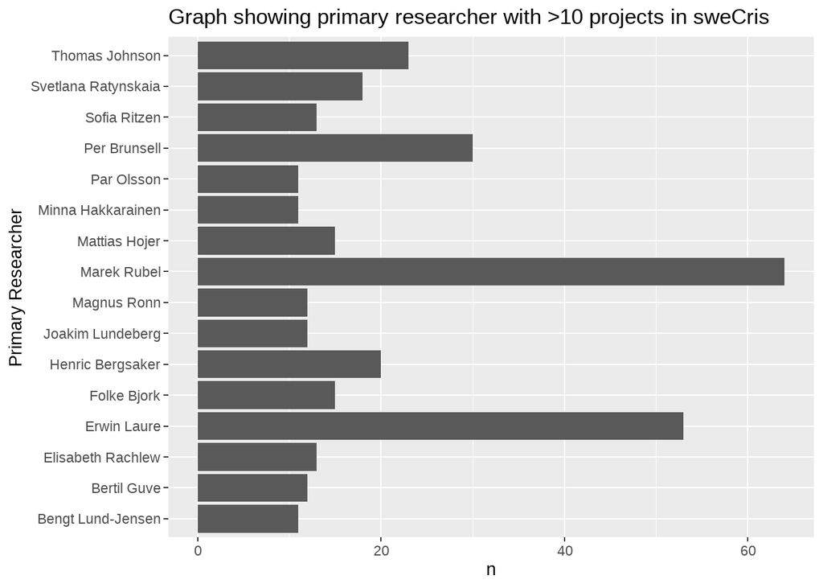

Primary Researchers in sweCris with projects > 10

```r
# Summarize.
sw.Df %>% group_by(Leading.Role) %>% count(sort = T)

sw.Df %>% group_by(PrimaryResearcher) %>%
  filter(!is.na(PrimaryResearcher)) %>%
  # filter(PrimaryResearcher != "Unknown") %>%
  count(sort = T) %>%
  filter(n > 10) %>%
  ggplot(aes(x = as.factor(PrimaryResearcher), y = n)) +
  geom_bar(stat = "identity", position = "dodge") +
  coord_flip() +
  labs(title = "Graph showing primary researcher with >10 projects in sweCris",
       x = "Primary Researcher")
```

```r
# Summarize (Case).
ca.Df %>%
  group_by(PrimaryResearcher) %>%
  count(sort = T)
```

```r
# Number of projects by Primary Researcher, along with Leading Role.
sw_primary <- sw.Df %>% group_by(PrimaryResearcher) %>% count(sort = T) %>%
  filter(n > 10) %>%
  ggplot(mapping = aes(x = reorder(PrimaryResearcher,-n), y = n)) +
  geom_col() + coord_flip() +
  labs(title = "Number of projects by Primary Researcher: n > 10")
```

```r
# swecris_project_people(project_id = "2021-00527_Formas")
```

```r
# Re-code.
sw.Df[is.na(sw.Df)] <- "Unknown"
sw.Df.Unknown <- subset(sw.Df,(Leading.Role %in% "Unknown"))
# Rows (n=17) were Involved People have limited information, but not PI name.
string.InNA <- which(grepl(pattern = "¤¤¤",x = sw.Df.Unknown$InvolvedPeople) == T)
# Subset to retain all NA.
sw.df.Partial <- sw.Df.Unknown[string.InNA, ]
```

```r
# Remove accent from primary research names in CASE.
ca.Df$PrimaryResearcher <- iconv(ca.Df$PrimaryResearcher,to = "ASCII//TRANSLIT")
# How many name matches?
generics::intersect(na.omit(ca.Df$PrimaryResearcher),
                    na.omit(sw.Df$PrimaryResearcher)) %>% unique()
generics::intersect(na.omit(ca.Df$PrimaryResearcher),
                    na.omit(sw.Df$PrimaryResearcher)) %>% unique() %>% length()
```

```r
Match.3A <- ca.Df %>%
  inner_join(sw.Df, by = c("PrimaryResearcher", "Name" = "ProjectTitleEn")) %>%
  filter(!is.na(PrimaryResearcher)) %>%
  filter(!duplicated(Name))

Match.3B <- ca.Df %>%
  inner_join(sw.Df, by = c("PrimaryResearcher", "Name" = "ProjectTitleSv")) %>%
  filter(!is.na(PrimaryResearcher)) %>%
  filter(!duplicated(Name))
Match.3C <- bind_rows(Match.3A,Match.3B) %>% filter(!duplicated(Name))
```

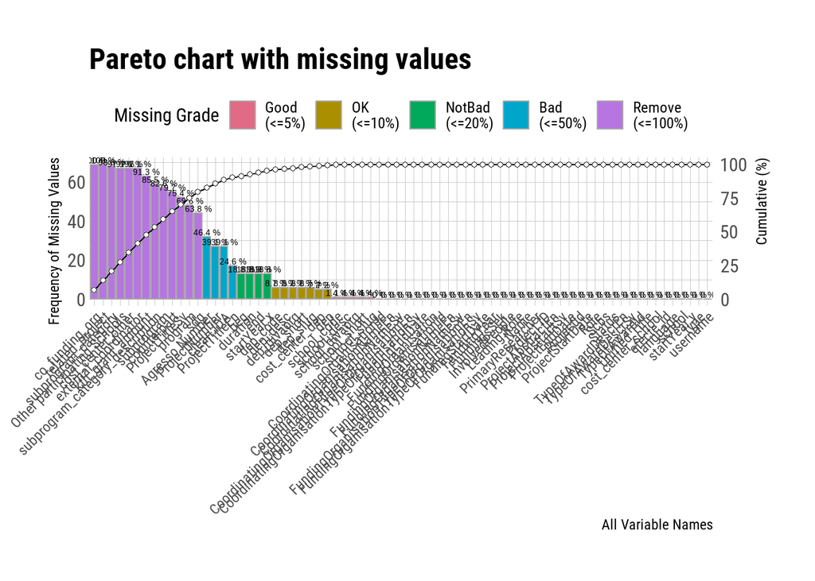

Pareto chart for missing values (counts and proportions) in the reduced CASE dataset.

```r
bazzi.na.Total(x = Match.3C, col = "black",typographic = T) +
  theme(axis.text.x = element_text(size = 9,angle = 45),
        axis.title.x = element_text(size = 9),
        axis.title.y = element_text(size = 9),
        axis.title.y.right = element_text(size = 9))
```

**Results (3/3)**

69 exact project matches based on Primary Researcher and Project Name.

```r
## Venn diagram showing projects overlap based on project title.
mP3 <- draw.pairwise.venn(area1= 3068,area2 = 746,
                          cross.area = 69,
                          category = c("SweCris: Primary Researcher",
                                       "CASE: PrimaryResearcher"),
                          fill = c("grey80","blue"),
                          cat.col = "black",cat.cex = 1,
                          scaled = T,cex = 1,
                          rotation.degree = 45)
```

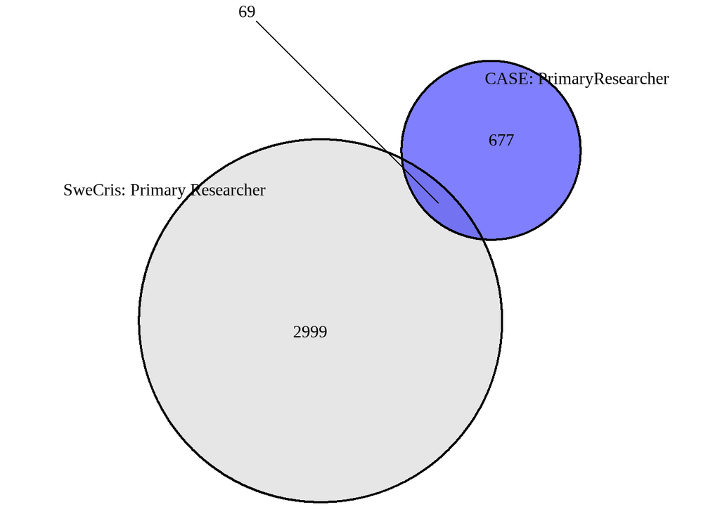

```r
ggarrange(mP3) + theme(aspect.ratio = 1)
```

```r
# Combine ID, Title, and Primary Research
Total.M2 <- merge(Total.M1,Match.3C,all = T)
Total.M2$Name <- tolower(iconv(Total.M2$Name,to = "ASCII//TRANSLIT"))
Total.M2 <- Total.M2 %>% filter(!duplicated(Name)) # 203 unique projects in total.

# And if limited to Research projects only.
Total.M3 <- Total.M2 %>% filter(type == "Research project") # 174 in total.
Total.M3 %>% group_by(FundingOrganisation) %>% count(sort = T)
```

```
# A tibble: 10 × 2
# Groups:   FundingOrganisation [10]
   FundingOrganisation       n
   <chr>                 <int>
 1 VINNOVA                  51
 2 Energimyndigheten        48
 3 Vinnova                  25
 4 VR                       22
 5 Formas                   18
 6 EU                        6
 7 Forte                     1
 8 Not Applicable N/A        1
 9 Other national funder     1
10 Rymdstyrelsen             1
```

```r
# Recode
Total.M3$FundingOrganisation <- recode(Total.M3$FundingOrganisation,
                                       Vinnova = "VINNOVA")
```

```r
knitr::kable(x = Total.M3 %>%
               group_by(FundingOrganisation) %>%
               count(sort = T), caption =
               "Table 4. Matched projects and corresponding funding organisation") %>%
  kable_styling()
```

Table 4. Matched projects and corresponding funding organisation

| FundingOrganisation | n |
| --- | --- |
| VINNOVA | 76 |
| Energimyndigheten | 48 |
| VR | 22 |
| Formas | 18 |
| EU | 6 |
| Forte | 1 |
| Not Applicable N/A | 1 |
| Other national funder | 1 |
| Rymdstyrelsen | 1 |

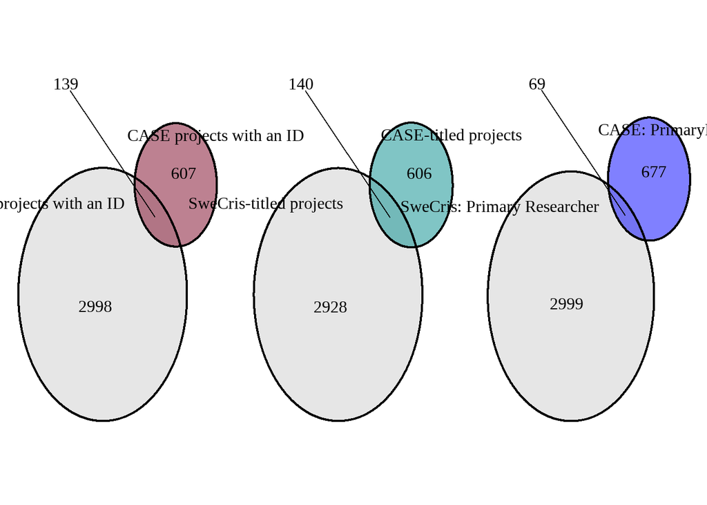

Venn diagram showing project overlap based on Id, Title, and Primary Researcher.

```r
ggarrange(mP1,mP2,mP3,nrow = 1,heights = c(2,2),widths = c(4,4)) +
  theme(aspect.ratio = 1/2)
```

```r
# Table preparations.
match_per_org <- Total.M3 %>%
  group_by(FundingOrganisation) %>%
  count(sort = T) %>%
  filter(FundingOrganisation != "Not Applicable N/A") %>%
  filter(FundingOrganisation != "Other national funder") %>%
  filter(FundingOrganisation != "EU") %>% ungroup() %>%
  add_row(FundingOrganisation = "Riksbankens Jubileumsfond",n = 0)

# Reorder
match_per_org <- match_per_org[c(4,5,7,6,2,3,1),]
# Combine.
Tab.4 <- cbind(Tab.3,match_per_org)
class(Tab.4) <- "data.frame"

# Remove redundant field.
Tab.4 <- Tab.4[,-c(3,5)]
# Rename columns.
colnames(Tab.4)[1] <- "Funding Organisation"
colnames(Tab.4)[2] <- "n_Swecris"
colnames(Tab.4)[3] <- "n_Case"
colnames(Tab.4)[4] <- "n_matches"
# Reorder
Tab.4 <- Tab.4[,c(1,3,2,4)]
# Proportions.
Tab.4["%_matched"] <- round(Tab.4[,4]/Tab.4[,2] * 100,digits = 0) # no decimal
# Sum of porject matches.
sum(Tab.4$n_matches) + 8 # 174 as in Total.M3 (Research Projects)
```

```
[1] 174
```

```r
knitr::kable(x = Tab.4,
caption = "Table 1. Summary of Agencies Involved in Project Funding for Case and Swecris. The Swecris dataset has seven funding agencies and the Case dataset has 29. The funding organization is unknown for 577 projects in Case. A hypothetical project match of 755 is assumed.") %>%
  kable_styling() %>%
  column_spec(4, bold = T, color = "white", background = "blue") %>%
  column_spec(5, bold = T, color = "white", background = "grey") %>%
  add_footnote(label = "6 research projects funded by the EU, 1 designated as Not Applicable, and 1 other national funder were also intersected (i.e. matched)",
               notation = "symbol",threeparttable = T)
```

| Funding Organisation | n_Case | n_Swecris | n_matches | %_matched |
| --- | --- | --- | --- | --- |
| Formas | 93 | 407 | 18 | 19 |
| Forte | 8 | 13 | 1 | 12 |
| Riksbankens Jubileumsfond | 6 | 12 | 0 | 0 |
| Rymdstyrelsen | 7 | 74 | 1 | 14 |
| Statens energimyndighet | 206 | 371 | 48 | 23 |
| Vetenskapsrådet | 119 | 1559 | 22 | 18 |
| Vinnova | 333 | 701 | 76 | 23 |

* 6 research projects funded by the EU, 1 designated as Not Applicable, and 1 other national funder were also intersected (i.e. matched)

## Section summary — Case vs sweCris

The main results revealed several issues with the data quality in the CASE dataset, particularly in the Project Number field which would benefit from a re-structuring and consistent ID formatting across projects to make database comparisons more efficient.

The results of the study found that the number of project matches depends on how ID standardization is done. Using the two predominant ID styles in sweCris as a reference, 139 distinct project matches were obtained. However, generally, most CASE IDs are written inconsistently, making it difficult to merge with sweCris. The issue is further compounded by variable ID formats in sweCris, although it is generally better than CASE. Out of 384 CASE projects with a clean ID, only 36% (N=139) could be matched against the sweCris dataset. Despite the low number of project matches, the added information retrieved from sweCris is generally complete (column-wise) as the data quality in sweCris tends to be better.

The results based on the primary researcher found that the InvolvedPeople column has a complex string structure with relevant information that ought to be parsed out to facilitate maximum matching with the CASE database. The name of 2441 Principal Investigators (77.81%) could be successfully collected via sweCris and 69 exact project matches between CASE and sweCris were found. In total, 203 unique projects can be matched based on ID, Title, and Primary Researcher. This means that of the 746 potential project fits, 27% were captured, with 73% missing.

**Ancillary remarks**. Obviously, a primary risk is the difficulty in integrating with other systems. (e.g. sweCris). Data quality is also a concern as Case have different levels of data quality. Additionally, if the databases are not representative of the population (e.g. ITM) being studied, it can lead to biased conclusions from the analysis. Lastly, if the databases contain duplicates, it can lead to confusion and inaccuracies in the analysis.

## 4. External Key: ORCID ID (KTH’s user database)

```r
# ugkthId & Orcid.
ug <- readr::read_csv(rawToChar(kthcorpus::minio_get("ug_kthid_orcid.csv",
                                                     bucket = "kthcorpus")))
# unique ugkthId.
lookup <- readr::read_csv(rawToChar(kthcorpus::minio_get("ug_kthid_unit.csv",
                                                         bucket = "kthcorpus")))
```

```r
# How many Primary Researchers in CASE dont have an CORCID ID?
# N = 131.
ca.Df %>%
  filter(type == "Research project") %>%
  group_by(username) %>% count() %>% arrange(desc(n)) %>%
  left_join(lookup, by = c("username" = "ugUsername")) %>%
  dplyr::select(username, ugOrcid, ugKthid, n) %>%
  filter(is.na(ugOrcid))
```

```
# A tibble: 134 × 4
# Groups:   username [134]
   username ugOrcid ugKthid     n
   <chr>    <chr>   <chr>   <int>
 1 regm     <NA>    <NA>       19
 2 larsges  <NA>    <NA>       11
 3 jeanna   <NA>    <NA>        7
 4 xiaoqli  <NA>    <NA>        7
 5 bergsman <NA>    <NA>        6
 6 glodic   <NA>    <NA>        6
 7 aman     <NA>    <NA>        5
 8 carmim   <NA>    <NA>        5
 9 maranti  <NA>    <NA>        5
10 samer    <NA>    <NA>        5
# … with 124 more rows
```

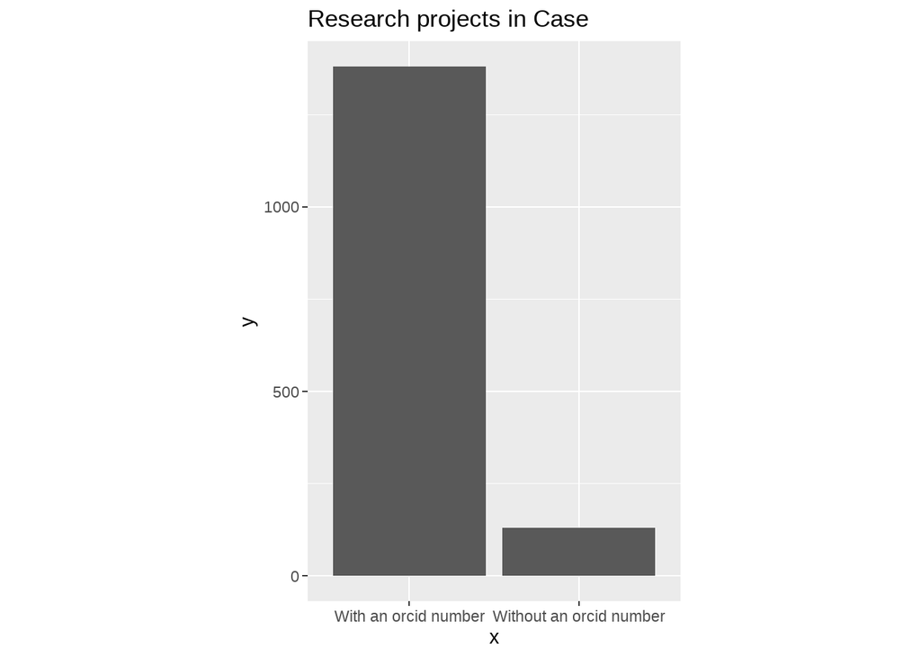

```r
# Merge by username and remove incomplete cases (subset by ugOrcid)
# N = 1380 research projects.
exDf.ca <- ca.Df %>%
  filter(type == "Research project") %>%
  left_join(lookup, by = c("username" = "ugUsername")) %>%
  filter(!is.na(ugOrcid)) %>%
  filter(!duplicated(Name))

sapply(exDf.ca[c("ProjectNumber","Name")],function(x) duplicated(x))

# Unique ORCID IDs (N = 470)
distinct.orcidID <- unique(exDf.ca$ugOrcid)
# Plot the data information.
avail_orcid <- data.frame(x = c("With an orcid number","Without an orcid number"),
                          y = c(1380,131))
avail_orcid %>%
  ggplot(mapping = aes(x = x, y = y)) +
  geom_col() + labs(title = "Research projects in Case") + theme(aspect.ratio = 1.5)
```

**Call sweCris api to get project results**

```r
# Initialize empty list to store the results
res <- list()
# Iterate over each ORCID ID
for (i in 1:470){
    orcid <- distinct.orcidID[i]
    res[[i]] <- tryCatch(swecris::swecris_projects_from_orcid(orcid),
                         error=function(e) e)
}

# Flatten.
op <- unlist(res,recursive = FALSE)
# Projects.
op_projects <- op[sapply(op, function(x) any(grepl("project", names(x))))]
projects <- do.call(rbind, op_projects)
projects <- projects %>% distinct()
# People list.
op_peopleList <- op[sapply(op, function(x) any(grepl("fullName", names(x))))]
peopleList  <- do.call(rbind,op_peopleList)
peopleList %>% group_by(fullName,roleEn) %>% count()
# Scbs.
op_scbs <- op[sapply(op, function(x) any(grepl("scb1NameEn", names(x))))]
scbs <- do.call(rbind, op_scbs)
```

A total of **986 projects** were retrieved by using orchid-ID’s associated with primary researchers at KTH. The question that arises is to what extent these projects align with those in CASE.

```r
# Match clean CASE data versus Orcid-data based on Project ID.
Match.4 <- cleanID.CASE %>%
  dplyr::inner_join(projects,by = c(clean.IDA = "projectId"),keep = TRUE)
```

```r
# Clean title names first a bit.
ca.Df <- ca.Df %>%
  mutate(clean_name =  gsub("\\s+"," ", iconv(tolower(ca.Df$Name),
                                              to = "ASCII//TRANSLIT")))

projects <- projects %>%
  mutate(clean_name_swe =  gsub("\\s+"," ", iconv(tolower(projects$projectTitleSv),
                                                  to = "ASCII//TRANSLIT"))) %>%
  mutate(clean_name_eng =  gsub("\\s+"," ", iconv(tolower(projects$projectTitleEn),
                                                  to = "ASCII//TRANSLIT")))
# Match.
Match.5A <- inner_join(ca.Df, projects, by = c("clean_name" = "clean_name_eng"))
Match.5B <- inner_join(ca.Df, projects, by = c("clean_name" = "clean_name_swe"))
Match.5C <- dplyr::bind_rows(Match.5A,Match.5B) # 72 project matches.
```

```r
# CASE copy
case.orcid <- ca.Df
# Fussy attempt on title.
Match.5D <- stringdist_inner_join(x = case.orcid[!is.na(case.orcid$Name),],
                                  y = projects,
                                  by = c("clean_name" = "clean_name_eng"))

Match.5E <- stringdist_inner_join(x = case.orcid[!is.na(case.orcid$Name),],
                                  y = projects,
                                  by = c("clean_name" = "clean_name_swe"))

Match.5F <- bind_rows(Match.5D,Match.5E)

# Plot matching results.
Orcid.Match.Res <- data.frame(ID = c("48","72","91"),
                              class = c("Exact match: Case vs Orcid ID",
                                        "Exact match: Case vs Orcid Title",
                                        "Fuzzy match: Case vs Orcid Title"))
```

## Section summary — Case vs Orcid

**Results:** Project overlap based on ID between the original Case data and sweCris downloaded data using orcid-id’s of Case listed primary researchers and here informed via the ug-file, only return an exact match of 48 projects. Conversely, a total of 72 exact matches could be returned or found using the title field instead. A fuzzy match based on project titles returned instead 91 observations.

## CORDIS

*CORDIS is the primary source of results from EU-funded projects.*

```r
# cordis::cordis_import(refresh = T)
cordis::cordis_schema()
```

```
# A tibble: 421 × 7
   tablename                  cid name             type    notnull dflt_…¹ pk
   <chr>                    <int> <chr>            <chr>   <lgl>   <chr>   <lgl>
 1 fp7_dm_proj_publications     0 PROJECT_ID       DOUBLE  FALSE   <NA>    FALSE
 2 fp7_dm_proj_publications     1 TITLE            VARCHAR FALSE   <NA>    FALSE
 3 fp7_dm_proj_publications     2 AUTHOR           VARCHAR FALSE   <NA>    FALSE
 4 fp7_dm_proj_publications     3 DOI              VARCHAR FALSE   <NA>    FALSE
 5 fp7_dm_proj_publications     4 PUBLICATION_TYPE VARCHAR FALSE   <NA>    FALSE
 6 fp7_dm_proj_publications     5 REPOSITORY_URL   VARCHAR FALSE   <NA>    FALSE
 7 fp7_dm_proj_publications     6 JOURNAL_TITLE    VARCHAR FALSE   <NA>    FALSE
 8 fp7_dm_proj_publications     7 PUBLISHER        VARCHAR FALSE   <NA>    FALSE
 9 fp7_dm_proj_publications     8 VOLUME           VARCHAR FALSE   <NA>    FALSE
10 fp7_dm_proj_publications     9 PAGES            VARCHAR FALSE   <NA>    FALSE
# … with 411 more rows, and abbreviated variable name ¹dflt_value
```

```r
cordis::cordis_tables() %>% print(n = 41)
```

```
# A tibble: 41 × 2
   table                              n_row
   <chr>                              <dbl>
 1 fp7_dm_proj_publications          305549
 2 fp7_euroSciVoc                     68651
 3 fp7_legalBasis                     25785
 4 fp7_organization                  140055
 5 fp7_project                        25785
 6 fp7_projectirps                     5293
 7 fp7_reportSummaries                21606
 8 fp7_topics                         26153
 9 fp7_webItem                        11767
10 fp7_webLink                         7989
11 h2020_euroSciVoc                  122551
12 h2020_legalBasis                   65784
```

[output cut: 29 more lines]

```r
# Connection.
con <- cordis_con()
```

```r
he_project_ids <- con |> tbl("he_organization") |>
  filter(shortName == "KTH") |> collect() |>
  distinct(projectID, projectAcronym) |>
  pull(projectID)

# HORIZON EUROPE projects
he_projects <-
  con |> tbl("he_project") |>
  filter(id %in% he_project_ids) |> collect()

fp7_project_ids <-
  con |> tbl("fp7_organization") |>
  filter(shortName == "KTH") |> collect() |>
  distinct(projectID, projectAcronym) |>
  pull(projectID)

# EU research projects under FP7
fp7_projects <- con |> tbl("fp7_project") |>
  filter(id %in% fp7_project_ids) |> collect() |>
  mutate(totalCost = readr::parse_number(totalCost))

# Horizon 2020 projects
h2020_project_ids <-
  con |> tbl("h2020_organization") |>
  filter(shortName == "KTH") |> collect() |>
  distinct(projectID, projectAcronym) |>
  pull(projectID)

h2020_projects <- con |> tbl("h2020_project") |>
  filter(id %in% h2020_project_ids) |> collect()

# Combine Horizon Europe, H2020 and FP7 projects into one table
kth_cordis <-
  list(h2020_projects, he_projects, fp7_projects) |> bind_rows() # 753 KTH projects.
```

```r
# EuroSciVoc taxonomy.
he_taxonomy <- con %>% tbl("he_euroSciVoc") %>%
  as.data.frame() %>%
  filter(projectID %in% kth_cordis$id) |> collect()

fp7_taxonomy <- con %>% tbl("fp7_euroSciVoc") %>%
  as.data.frame() %>%
  filter(projectID %in% kth_cordis$id) |> collect()

h2020_taxonomy <- con %>% tbl("h2020_euroSciVoc") %>%
  as.data.frame() %>%
  filter(projectID %in% kth_cordis$id) |> collect()

# Joint list
taxonomy_df <- list(he_taxonomy,fp7_taxonomy,h2020_taxonomy) %>%
  bind_rows()
```

```r
# Plot funding schemes in cordis.
cordis_funding_org <- kth_cordis %>%
  group_by(fundingScheme) %>%
  count() %>%
  ggplot(mapping = aes(x = reorder(fundingScheme, -n),y = n)) +
  labs(title = "Funding Scheme", x = "") + coord_flip() +
  geom_col() + theme(axis.text.x = element_text(angle = 45)) +
  theme(axis.text.y = element_text(size = 3.5))

# Plot completness in cordis.
cordis_quality <- bazzi.na.Total(kth_cordis)

# Funding size plot
range(kth_cordis$totalCost) # there are some format issue here.
```

```
[1]           0 17236976762
```

```r
# Plot subject areas
cordis_master <- kth_cordis %>%
  mutate(id_clean = as.numeric(id)) %>%
  inner_join(taxonomy_df[!duplicated(taxonomy_df$projectID),],
             by = c("id_clean" = "projectID"))

cordis_subjects <- cordis_master %>%
  group_by(euroSciVocTitle) %>%
  count(sort = T) %>%
  filter(n > 5) %>%
  ggplot(mapping = aes(x = euroSciVocTitle, y = n)) +
  geom_col() + theme(axis.text.x = element_text(size = 4),
                     axis.text.y = element_text(size = 4)) + coord_flip() +
  labs(title = "Subject categories: n > 5", x = "")

# Disconnect.
# on.exit(cordis_disconnect(con))
```

#### Cordis vs Case intersection

```r
# Title match? 231 exact matches.
cordis_match_a <- kth_cordis %>%
  dplyr::inner_join(ca.Df,
                    by = c("title" = "Name"),
                    multiple = "all") %>%
  filter(!duplicated(title))

# In terms of project matches, what are the funding calls?
cordis_match_funding <- cordis_match_a %>%
  group_by(fundingScheme) %>%
  count(sort = T) %>% ggplot(mapping = aes(x = reorder(fundingScheme,-n), y = n)) +
  geom_col() + coord_flip() +
  labs(title = "Cordis vs. Case project matches: Funding Schemes")

# Fuzzy matching? 256 project matches.
cordis_match_b <-
  ca.Df[!is.na(ca.Df$Name),] %>%
  stringdist_inner_join(kth_cordis, by = c("Name" = "title"), max_dist = 1) %>%
  filter(!duplicated(title))
```

[figure not shown]

```r
# Veen diagram of the above results.
mP4 <- draw.pairwise.venn(area1 = 2611,area2 = 753,
                          cross.area = 231,
                          category = c("Cordis: Title",
                                       "Case: Title"),
                          fill = c("grey80","blue"),
                          cat.col = "black",cat.cex = 1,
                          scaled = T,cex = 1,
                          rotation.degree = 45)
```

#### Cordis vs sweCris

```r
# sweCris versus Cordis using title. Only 6 projects.
cordis_match_c <- sw.Df %>%
  inner_join(kth_cordis, by = c("ProjectTitleEn" = "title"))
```

## OpenAIRE

```r
open_aire_kth_xml <- openaire_crawl("projects", page_size = 100, params = api_params(
  format = "xml",
  proj_country = "SE",
  proj_org = "Royal Institute of Technology"))

open_aire_kth_tsv <- openaire_crawl("projects", page_size = 100, params = api_params(
  format = "tsv",
  proj_country = "SE",
  proj_org = "Royal Institute of Technology"))
```

```r
# Generate a handful of graphs reflecting openAIRE data content
openAire_quality <- bazzi.na.Total(open_aire_kth_xml)
# Plot funding details.
openAire_funding_org <- open_aire_kth_xml %>%
  group_by(funder_name) %>%
  count() %>%
  ggplot(mapping = aes(x = reorder(funder_name, -n),y = n)) +
  labs(title = "openAire",x = "") + coord_flip() +
  geom_col() + theme(axis.text.x = element_text(angle = 45))

# OA is mandated
openAire_OA_A <- open_aire_kth_xml %>%
  group_by(oa_is_mandated) %>% count(sort = T) %>%
  ggplot(aes(x = oa_is_mandated, y = n, fill = oa_is_mandated)) +
  geom_col() + labs(x = "", title = "Funding requirement")

# Add new variable.
open_aire_kth_xml["startYear"] <-
  format(as.Date(open_aire_kth_xml$beg_date),"%Y")

openAire_OA_B <-
  open_aire_kth_xml %>% group_by(oa_is_mandated,startYear) %>% count(sort = T) %>%
  ggplot(aes(x = startYear, y = n, fill = oa_is_mandated)) +
  geom_bar(stat = "identity") +
  theme(axis.text.x = element_text(angle = 45,size = 6)) +
  labs(x = "", title = "OA mandated projects over time")
```

#### openAire versus Case

```r
# Project match on title.
Match.7A <- ca.Df %>%
  inner_join(open_aire_kth_tsv, by = c("Name" = "Project title"), keep = T)

# ... 225 project matches.
Match.7B <- ca.Df %>%
  inner_join(open_aire_kth_xml, by = c("Name" = "title"), keep = T)
```

#### openAire versus Swecris

```r
# Match against sweCris
Match.7C <- sw.Df %>%
  inner_join(open_aire_kth_xml, by = c("ProjectTitleEn" = "title"), keep = T) # 6 only
```

#### openAire versus Cordis (Title)

```r
# 1. Cordis verus openAire using title.
cordis_vs_openAire_a <- kth_cordis %>%
  inner_join(open_aire_kth_xml, by = "title", multiple = "all") %>%
  filter(!duplicated(title)) # 664 KTH projects.

# 2. Fuzzy matching
cordis_vs_openAire_b <- kth_cordis %>%
  stringdist_inner_join(open_aire_kth_xml, by = "title") %>%
  filter(!duplicated(title.x)) %>%
  mutate(id = as.numeric(id)) # 691 projects.

# 3. Anti-join to see the differences.
cordis_vs_openAire_c <- dplyr::anti_join(x = cordis_vs_openAire_b,
                                         y = cordis_vs_openAire_a)
```

#### openAire versus Cordis (ID)

```r
kth_cordis$id <- as.character(kth_cordis$id)
# Match
# cordis_vs_openAire_c <- open_aire_kth_xml %>%
#  inner_join(kth_cordis, by = c("clean.ID" = "id")) # 385
```

## Combine all data-sources

```r
df_list <- list(Total.M3,cordis_match_a,Match.7B,cordis_vs_openAire_a)

joined_df <- Reduce(function(x, y) merge(x, y, all=TRUE), df_list) %>%
  filter(!duplicated(title))
```